# Comparing how well decision algorithms can handle missing data

Jelena Meyer and Hansjörg Neth

2024-01-14

### Introduction

For a binary decision problem (True/False) different algorithms can use available information (= predictive variables) and predict a specified outcome variable. Here we compare FFTrees and logistic regression.

Both decision models are fitted on training data, the models are saved and new test data is then predicted by it.

In this analysis we focus on the performance of the two models when they face data with missings. We compare different algorithms’ **accuracy** in classifying different data with missings.

### FFTrees

The FFTree package automatically handles missing data: As soon as missing data arises in the next decision node of the model tree, the case is simply handed over to the next node. This is done so long until info for one node is available and the tree can classify the case. If all further variables of the case are missing the tree classifies according to the baseline of the criterion.

### Logisitic Regression

In logistic regression there are multiple ways to handle missings.

The easiest one is listwise deletion (= Complete Case Analysis CCA). Here, all cases where a single variable is missing are excluded and the case is not classified. For this graphical illustration we figured that in reality one would classify the case with baseline accuracy if the algorithm gave no answer, therefore the accuracy score is the sum of all classified cases times their accuracy plus all not classified cases times the baseline accuracy divided by the total number of cases in the data set.

When doing CCA, there is a steep slope of loss in information, resulting in one having no classified data anymore when 20-30 percent of every predictive variable (all data) is missing. Therefore we implemented a simpler version that is similar to well-known subset selection methods. We looked for a summary of the original regression model and made a subset of data with only the significant predictive variables and the criterion. We think that gives CCA a better chance to compete, since every missing data point in uninformative predictors would otherwise lead to case deletion. The second CCA method is implemented exactly as the first one except for operating on a different data set.

Whenever an algorithm did not classify anymore (due to logged events or simply no information) we set their accuracy to baseline-level.

### Results:

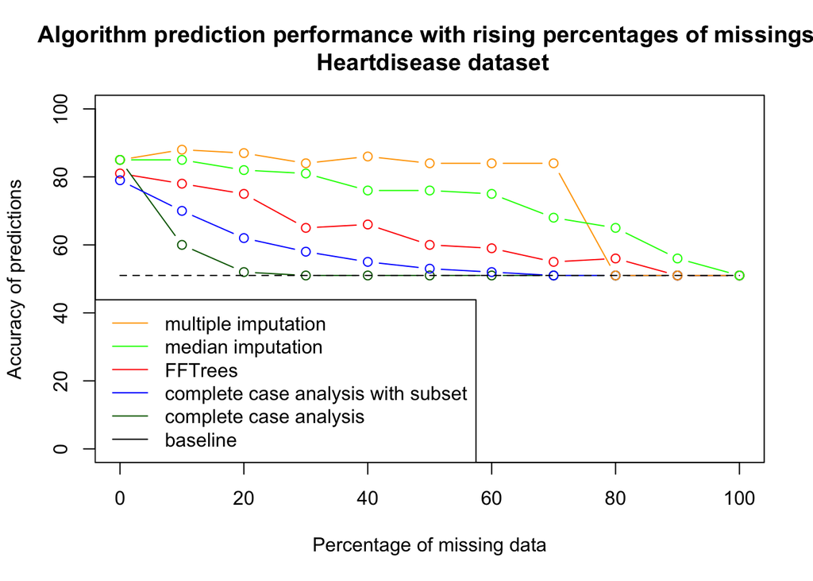

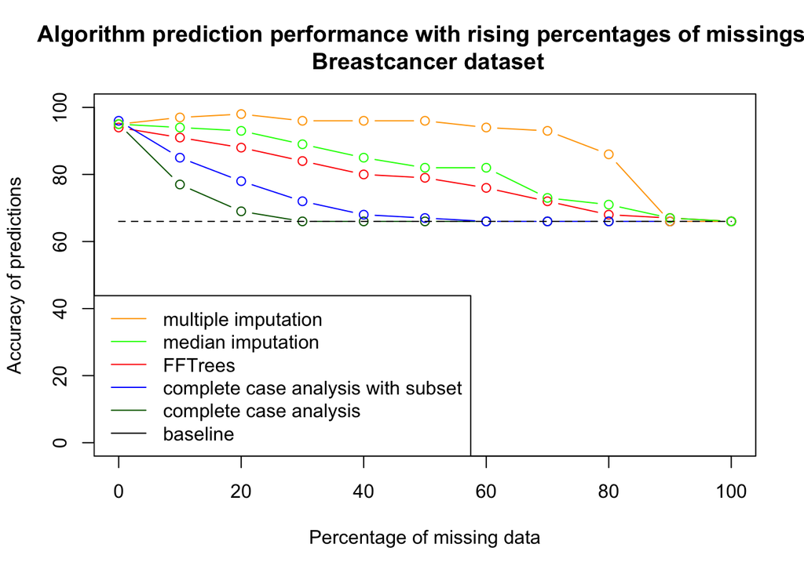